# Association between variables

An interactive walkthrough

## What can we compare?

| Variables | What to look at | Measure |
| --- | --- | --- |
| Two binary variables | Event frequency in each group | Risk difference, risk ratio, odds ratio |
| A numerical outcome in two groups | Where each group is centred | Difference in means |
| Two numerical variables | Shape, direction and spread of the point cloud | Pearson’s *r* for linear association |
| Ordered or numerical variables | How consistently the observations are ordered | Spearman’s ρ or Kendall’s τ |

**Start with the table or plot.** Then choose what the number should describe.

## Who goes in the denominator?

| Group | Died | Recovered |
| --- | --- | --- |
| **Placebo** | 10 | 6 |
| Treatment | 8 | 12 |

**Placebo group.** Each dot is one patient. ● Died · ● Recovered

**Risk**

What fraction of the group died?

**10** who died

**16** patients in the group

10/16 = **0.625**

**Odds**

How many deaths were there per recovery?

**10** who died

**6** who recovered

10/6 ≈ **1.67**

## Three ways to compare the same groups

■ Placebo · ■ Treatment (reference)

Risk on placebo · **0.625**

Risk on treatment · **0.400**

**RD** = 0.625 − 0.400 = **0.225**

The striped segment shows the absolute difference. Here that is about 23 more deaths per 100 patients on placebo.

Risk on placebo · **0.625**

Risk on treatment · **0.400**

**RR** = 0.625 ÷ 0.400 ≈ **1.56**

Placebo risk is about 1.56 times the treatment risk. Report RR with RD to show both the relative and absolute difference.

Placebo · 10 died, 6 recovered

Treatment · 8 died, 12 recovered

**OR** = 10/6 ÷ 8/12 = **2.50**

Placebo odds are 2.50 times the treatment odds.

**Case–control studies.** Sampling by outcome makes the sample event fractions unsuitable for estimating population RD or RR directly. OR can be used when the sampling is appropriate.

## One table, three measures

Transpose table

| Group | Died | Recovered |
| --- | --- | --- |
| Placebo |  |  |
| Treatment |  |  |

Event: death

| Group | Risk | Odds |
| --- | --- | --- |

RD · risk difference

RR · risk ratio

OR · odds ratio

Edit any count. Odds are the event count divided by the non-event count.

Walk through

## How far apart are the group means?

Shift group A

[interactive chart not shown]

Group A mean

Group B mean

Mean difference · A − B

The diamonds mark the means. The difference is measured in laugh-score points.

## Three correlations on the same points

Pattern Add an outlier

[interactive chart not shown]

Pearson’s rLinear association

Spearman’s ρPearson on ranks

Kendall’s τ-bAgreement in pair order, with a tie adjustment

## Where do the correlation numbers come from?

Three students have study times **1, 2, 3 hours** and scores **10, 40, 20**.

| Measure | What it measures and how it is calculated | Result |
| --- | --- | --- |
| **Pearson** | How closely the points follow a rising or falling straight line. Multiply the paired deviations from the means, sum the products, and divide by the product of the two centred columns’ lengths. | *r* ≈ **0.33** |
| **Spearman** | How consistently higher study times go with higher or lower scores. Replace the values by their ranks, then apply Pearson’s formula to **(1, 2, 3)** and **(1, 3, 2)**. | ρ = **0.50** |
| **Kendall** | How often the two variables order pairs of students the same way. Here, two pairs agree and one disagrees. With no ties, divide their difference by all three pairs to get **(2 − 1) / 3**. | τ = **0.33** |

## Calculate a correlation step by step

If the highest score changes from 40 to 80, which measures will change?

Coefficient

| Student | Hours | Score |
| --- | --- | --- |

## Reading Pearson’s `cor.test()`

| Output | Value | Interpretation |
| --- | --- | --- |
| Sample correlation | **0.73** | Direction and strength |
| 95% confidence interval | **[0.49, 0.87]** | Precision of the estimate |
| p-value | **<0.001** | Evidence against zero population correlation |

```r
cor.test(plant_height_df$Sunlight_hrs_per_day, plant_height_df$Plant_height)
```

The null hypothesis is H₀ (ρ = 0). The interval shows which population correlations are compatible with the data under the model.

## Anscombe’s quartet

Each dataset has Pearson’s **r ≈ 0.82**. What changes when you look at the plots?

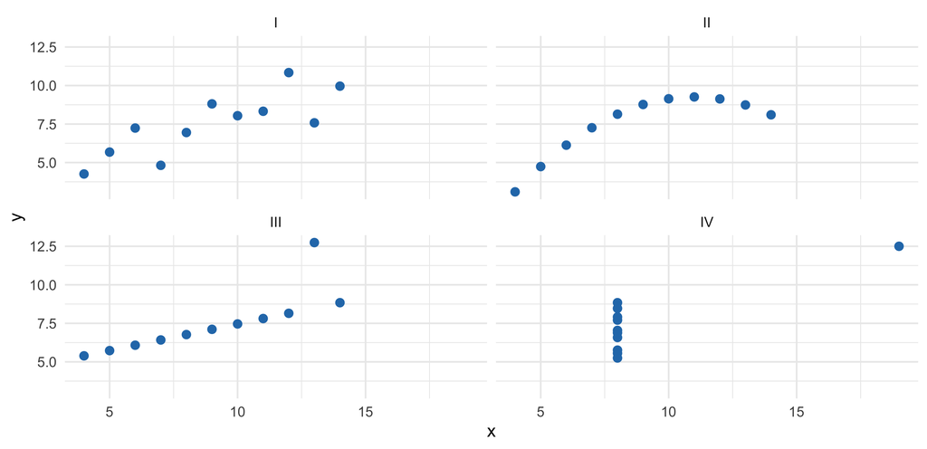

## When grades overlap

Size points by count

[interactive chart not shown]

Spearman’s ρ

Kendall’s τ-b

## Simpson’s paradox in the iris data

Show species and within-species correlations

[interactive chart not shown]

**What flips?** The pooled correlation is negative. Within each species it is positive.

**What to do.** Colour the points by species and calculate the correlation separately for each species. Show the pooled correlation alongside them. For a question about flowers of the same species, interpret the within-species correlations.

## When to use mean differences or correlations

| Measure | What it tells you | What to check |
| --- | --- | --- |
| **Mean difference** | How far apart the means of a numerical outcome are in two groups | Plot both distributions. Check whether outliers pull the means. |
| **Pearson’s r** | Direction and strength of a linear association between paired numerical values | Check the scatterplot for curvature and influential points. |
| **Spearman’s ρ** | How closely the ranks follow an increasing or decreasing pattern | Use it with ordinal or numerical data when a monotone relationship is the question. |
| **Kendall’s τ-b** | How consistently pairs are ordered in the same direction | Use it with ordinal or numerical data when pairwise agreement is the question. It accounts for ties. |

A correlation near zero can occur with a strong U-shaped pattern. Use the plot to check the shape. A correlation alone cannot establish causation.

## Try it in R

1. **Arthritis.** Define the event as marked improvement. Compute RD, RR and OR using the same event throughout.
2. **Diamonds.** Plot the pair first. Is the association linear, monotone, or neither?
3. **Iris.** Compute the pooled correlation and compare it with the three within-species correlations.

The course practical, **Association between variables**, contains the data and worked examples.